# Case Study 1 : Validating the customer eligibility of Loan using bagging classifier.

On the basis of below details, We are going to decide whether customer is eligible to get loan or not?

Dataset :

Loan_ID :Unique Loan ID

Gender: Male/ Female

Married Applicant married: (Y/N)

Dependents: Number of dependents

Education: Applicant Education (Graduate/ Under Graduate)

Self_Employed: Self employed (Y/N)

ApplicantIncome: Applicant income

CoapplicantIncome: Coapplicant income

LoanAmount: Loan amount in thousand

Loan_Amount_Term: Term of loan in months

Credit_History: credit history meets guidelines

Property_Area: Urban/ Semi Urban/ Rural

Loan_Status: Loan approved (Y/N) #This is our label/ output variable.

```python
import pandas as pd
import numpy as np
```

# 1) Acquire the data

```python
df=pd.read_csv('train.csv')
```

```python
df.head()
```

|  | Loan_ID | Gender | Married | Dependents | Education | Self_Employed | ApplicantIncome | CoapplicantIncome | LoanAmount | Loan_Amount_Term | Credit_History | Property_Area | Loan_Status |
| --- | --- | --- | --- | --- | --- | --- | --- | --- | --- | --- | --- | --- | --- |
| 0 | LP001002 | Male | No | 0 | Graduate | No | 5849 | 0.0 | NaN | 360.0 | 1.0 | Urban | Y |
| 1 | LP001003 | Male | Yes | 1 | Graduate | No | 4583 | 1508.0 | 128.0 | 360.0 | 1.0 | Rural | N |
| 2 | LP001005 | Male | Yes | 0 | Graduate | Yes | 3000 | 0.0 | 66.0 | 360.0 | 1.0 | Urban | Y |
| 3 | LP001006 | Male | Yes | 0 | Not Graduate | No | 2583 | 2358.0 | 120.0 | 360.0 | 1.0 | Urban | Y |
| 4 | LP001008 | Male | No | 0 | Graduate | No | 6000 | 0.0 | 141.0 | 360.0 | 1.0 | Urban | Y |

```python
df.shape
```

```
(614, 13)
```

# 2) Preprocess the data

Now we can observe that there are columns with missing values we have to impute them

```python
null_counts=df.isnull().sum()
null_counts
```

```
Loan_ID               0
Gender               13
Married               3
Dependents           15
Education             0
Self_Employed        32
ApplicantIncome       0
CoapplicantIncome     0
LoanAmount           22
Loan_Amount_Term     14
Credit_History       50
Property_Area         0
Loan_Status           0
dtype: int64
```

```python
df['Gender'].fillna(df['Gender'].mode()[0], inplace=True)
df['Married'].fillna(df['Married'].mode()[0], inplace=True)
df['Dependents'].fillna(df['Dependents'].mode()[0], inplace=True)
df['Self_Employed'].fillna(df['Self_Employed'].mode()[0],inplace=True)
df['LoanAmount'].fillna(df['LoanAmount'].mean(),inplace=True)
df['Loan_Amount_Term'].fillna(df['Loan_Amount_Term'].mode()[0], inplace=True)
df['Credit_History'].fillna(df['Credit_History'].mode()[0], inplace=True)
```

Now as we can see from the data head there are certain features that are categorical which needs to be converted to numeric.

```python
from sklearn.preprocessing import LabelEncoder
```

```python
var_mod = ['Loan_ID','Gender','Married','Dependents','Education','Self_Employed','Property_Area','Loan_Status']
le = LabelEncoder()
for i in var_mod:
    df[i] = le.fit_transform(df[i])
df.dtypes
```

```
Loan_ID                int32
Gender                 int32
Married                int32
Dependents             int32
Education              int32
Self_Employed          int32
ApplicantIncome        int64
CoapplicantIncome    float64
LoanAmount           float64
Loan_Amount_Term     float64
Credit_History       float64
Property_Area          int32
Loan_Status            int32
dtype: object
```

```python
df.head()
```

|  | Loan_ID | Gender | Married | Dependents | Education | Self_Employed | ApplicantIncome | CoapplicantIncome | LoanAmount | Loan_Amount_Term | Credit_History | Property_Area | Loan_Status |
| --- | --- | --- | --- | --- | --- | --- | --- | --- | --- | --- | --- | --- | --- |
| 0 | 0 | 1 | 0 | 0 | 0 | 0 | 5849 | 0.0 | 146.412162 | 360.0 | 1.0 | 2 | 1 |
| 1 | 1 | 1 | 1 | 1 | 0 | 0 | 4583 | 1508.0 | 128.000000 | 360.0 | 1.0 | 0 | 0 |
| 2 | 2 | 1 | 1 | 0 | 0 | 1 | 3000 | 0.0 | 66.000000 | 360.0 | 1.0 | 2 | 1 |
| 3 | 3 | 1 | 1 | 0 | 1 | 0 | 2583 | 2358.0 | 120.000000 | 360.0 | 1.0 | 2 | 1 |
| 4 | 4 | 1 | 0 | 0 | 0 | 0 | 6000 | 0.0 | 141.000000 | 360.0 | 1.0 | 2 | 1 |

```python
df.describe()
```

|  | Loan_ID | Gender | Married | Dependents | Education | Self_Employed | ApplicantIncome | CoapplicantIncome | LoanAmount | Loan_Amount_Term | Credit_History | Property_Area | Loan_Status |
| --- | --- | --- | --- | --- | --- | --- | --- | --- | --- | --- | --- | --- | --- |
| count | 614.000000 | 614.000000 | 614.000000 | 614.000000 | 614.000000 | 614.000000 | 614.000000 | 614.000000 | 614.000000 | 614.000000 | 614.000000 | 614.000000 | 614.000000 |
| mean | 306.500000 | 0.817590 | 0.653094 | 0.744300 | 0.218241 | 0.133550 | 5403.459283 | 1621.245798 | 146.412162 | 342.410423 | 0.855049 | 1.037459 | 0.687296 |
| std | 177.390811 | 0.386497 | 0.476373 | 1.009623 | 0.413389 | 0.340446 | 6109.041673 | 2926.248369 | 84.037468 | 64.428629 | 0.352339 | 0.787482 | 0.463973 |
| min | 0.000000 | 0.000000 | 0.000000 | 0.000000 | 0.000000 | 0.000000 | 150.000000 | 0.000000 | 9.000000 | 12.000000 | 0.000000 | 0.000000 | 0.000000 |
| 25% | 153.250000 | 1.000000 | 0.000000 | 0.000000 | 0.000000 | 0.000000 | 2877.500000 | 0.000000 | 100.250000 | 360.000000 | 1.000000 | 0.000000 | 0.000000 |
| 50% | 306.500000 | 1.000000 | 1.000000 | 0.000000 | 0.000000 | 0.000000 | 3812.500000 | 1188.500000 | 129.000000 | 360.000000 | 1.000000 | 1.000000 | 1.000000 |
| 75% | 459.750000 | 1.000000 | 1.000000 | 1.000000 | 0.000000 | 0.000000 | 5795.000000 | 2297.250000 | 164.750000 | 360.000000 | 1.000000 | 2.000000 | 1.000000 |
| max | 613.000000 | 1.000000 | 1.000000 | 3.000000 | 1.000000 | 1.000000 | 81000.000000 | 41667.000000 | 700.000000 | 480.000000 | 1.000000 | 2.000000 | 1.000000 |

Divide data into train and test

```python
from sklearn.model_selection import train_test_split
```

```python
train,test=train_test_split(df,test_size=0.2,random_state=100)
```

```python
X_train=train.drop('Loan_Status',axis=1)
y_train=train['Loan_Status']
```

```python
X_test=train.drop('Loan_Status',axis=1)
y_test=train['Loan_Status']
```

```python
from sklearn.preprocessing import StandardScaler # Scaling for normalization
```

Every sklearn's transform's fit() just calculates the parameters (e.g. μ and σ in case of StandardScaler) and saves them as an internal objects state. Afterwards, you can call its transform() method to apply the transformation to a particular set of examples.

fit_transform() joins these two steps and is used for the initial fitting of parameters on the training set x, but it also returns a transformed x′. Internally, it just calls first fit() and then transform() on the same data.

Transform means conversion into z score. fit_transform means conversion into z score on the basis of mean and std.

```python
sc=StandardScaler()
```

```python
X_train=sc.fit_transform(X_train)
```

```python
X_test=sc.transform(X_test)
```

```python
X_train
```

```
array([[ 1.52807035,  0.4672925 ,  0.717936  , ...,  0.27808264,
         0.40094451, -0.041725  ],
       [-0.75662823,  0.4672925 ,  0.717936  , ..., -0.65328555,
         0.40094451,  1.23871089],
       [ 0.12777122,  0.4672925 ,  0.717936  , ...,  0.27808264,
         0.40094451, -0.041725  ],
       ...,
       [ 0.25816345,  0.4672925 ,  0.717936  , ...,  0.27808264,
         0.40094451, -0.041725  ],
       [-1.27819714,  0.4672925 ,  0.717936  , ...,  0.27808264,
         0.40094451, -0.041725  ],
       [ 1.22193208,  0.4672925 ,  0.717936  , ...,  0.27808264,
         0.40094451, -0.041725  ]])
```

# 3) Train the model

```python
from sklearn.ensemble import BaggingClassifier
from sklearn.tree import DecisionTreeClassifier
```

```python
my_model = BaggingClassifier(DecisionTreeClassifier(), n_estimators=500, max_samples=100, bootstrap=True, n_jobs=-1)
#n_estimators means no of trees to be used in forest.
#max_samples means no of samples to be drawn from X to train each base estimator
#bootstrap = sampling with replacement (repetative)
```

```python
result = my_model.fit(X_train, y_train)
```

# 4) Test the model

```python
predictions = result.predict(X_test)
```

```python
predictions
```

```
array([1, 1, 1, 1, 1, 1, 1, 1, 1, 0, 1, 0, 0, 1, 1, 1, 1, 1, 1, 0, 1, 1,
       1, 0, 1, 1, 1, 1, 1, 1, 1, 1, 0, 1, 1, 1, 1, 1, 1, 1, 1, 1, 1, 1,
       0, 1, 1, 1, 1, 1, 1, 1, 1, 1, 1, 1, 1, 1, 1, 1, 1, 1, 1, 1, 1, 1,
       1, 1, 1, 1, 1, 1, 1, 1, 1, 1, 1, 1, 0, 0, 1, 1, 1, 1, 1, 1, 1, 1,
       0, 1, 1, 1, 1, 1, 1, 1, 1, 1, 1, 1, 1, 1, 0, 1, 1, 0, 1, 1, 1, 1,
       1, 0, 1, 1, 1, 1, 1, 1, 0, 1, 1, 1, 0, 1, 1, 1, 1, 1, 0, 1, 1, 1,
       0, 1, 1, 1, 0, 1, 1, 1, 1, 1, 1, 1, 1, 1, 1, 1, 1, 1, 1, 1, 0, 1,
       1, 1, 1, 1, 1, 1, 1, 1, 1, 1, 1, 0, 1, 1, 1, 1, 1, 0, 1, 1, 1, 1,
       0, 0, 1, 1, 1, 1, 1, 1, 1, 0, 1, 1, 1, 1, 1, 1, 1, 1, 1, 1, 1, 1,
       1, 1, 1, 1, 1, 1, 1, 1, 1, 1, 1, 1, 1, 1, 1, 1, 1, 1, 1, 1, 1, 1,
       1, 1, 0, 1, 1, 0, 1, 1, 1, 1, 1, 1, 1, 0, 1, 1, 1, 1, 1, 0, 1, 1,
       1, 1, 1, 1, 1, 1, 1, 0, 1, 1, 1, 1, 1, 1, 1, 1, 0, 1, 0, 1, 1, 0,
       1, 1, 1, 1, 1, 1, 1, 1, 0, 1, 1, 1, 1, 0, 1, 1, 1, 1, 1, 0, 1, 1,
       0, 1, 1, 1, 1, 1, 1, 0, 0, 0, 0, 1, 0, 1, 1, 1, 1, 1, 1, 1, 1, 1,
       1, 1, 0, 0, 1, 1, 1, 1, 1, 1, 1, 0, 1, 1, 1, 1, 1, 1, 1, 1, 1, 0,
       1, 1, 1, 1, 1, 1, 1, 1, 1, 1, 1, 1, 1, 0, 1, 1, 1, 1, 1, 0, 1, 1,
       1, 1, 1, 1, 1, 0, 0, 1, 1, 1, 1, 0, 1, 1, 1, 1, 1, 1, 1, 1, 0, 1,
       0, 1, 1, 1, 1, 1, 1, 1, 1, 1, 1, 1, 0, 0, 1, 1, 1, 1, 1, 1, 0, 1,
       0, 1, 0, 1, 0, 1, 1, 1, 1, 1, 1, 1, 1, 1, 0, 0, 1, 0, 0, 1, 1, 1,
       1, 0, 1, 1, 1, 0, 1, 1, 1, 1, 1, 1, 1, 1, 1, 0, 0, 1, 1, 1, 1, 1,
       1, 1, 1, 1, 1, 1, 1, 1, 1, 1, 1, 1, 0, 1, 1, 1, 1, 1, 1, 1, 1, 0,
       1, 1, 1, 0, 1, 1, 1, 1, 1, 0, 1, 1, 1, 1, 1, 1, 1, 1, 1, 1, 1, 1,
       0, 1, 1, 1, 1, 1, 1])
```

```python
from sklearn.metrics import accuracy_score
accuracy_score(y_test,predictions)
```

```
0.835030549898167
```

```python
from sklearn.metrics import confusion_matrix
```

```python
import seaborn as sn
conf_matrix =confusion_matrix(predictions,y_test)
confusion_df = pd.DataFrame(conf_matrix, index=['Actual neg','Actual pos'], columns=['Predicted neg','Predicted pos'])
```

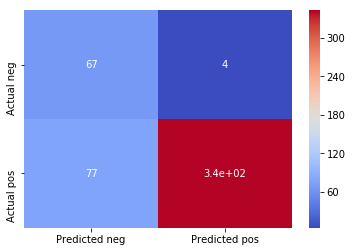

```python
sn.heatmap(confusion_df, cmap='coolwarm', annot=True)
```

```python
from sklearn import metrics
print('\n**Classification Report:\n',metrics.classification_report(y_test,predictions))
```

```
**Classification Report:
               precision    recall  f1-score   support

           0       0.94      0.47      0.62       144
           1       0.82      0.99      0.89       347

   micro avg       0.84      0.84      0.84       491
   macro avg       0.88      0.73      0.76       491
weighted avg       0.85      0.84      0.81       491
```

# 5) Deploy the model

```python
pred_new=list(result.predict([[0,1,0,0,0,0,5849,0.0,146.412162,360.0,1.0,2]]))
```

```python
pred_new
```

```
[1]
```

The fundamental difference between bagging and Random forest is that in Random forests, only a subset of features are selected at random out of the total and the best split feature from the subset is used to split each node in a tree, unlike in bagging where all features are considered for splitting a node.